# Time Series Analysis for Banks

###### **Insights:**

Segment 2 has more number of applicants in middle of the month (11 - 25).

Segment 1 has more number of applicants during the last days of the month (29 - 31)

```r
# 8. TimeSeries based on the segment
df_csv$segment = as.factor(df_csv$segment)
na_trend<- df_csv %>% group_by(segment,application_date) %>%
  summarise(No_cases = sum(no_of_applicants))
```

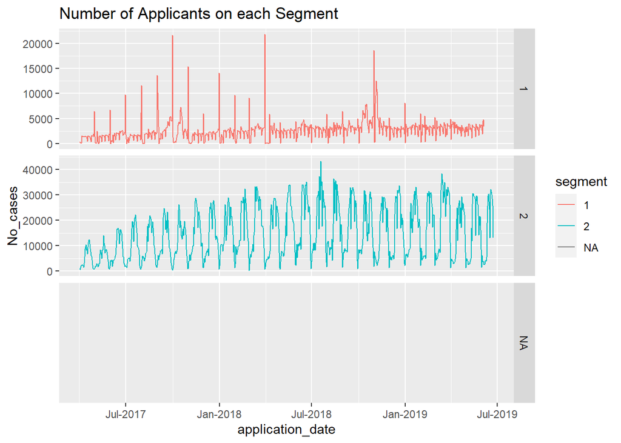

```r
ggplot(na_trend,aes(x = application_date,y = No_cases,color = segment))+geom_line(stat = "identity")+labs(title = "Number of Applicants on each Segment")+scale_x_date(date_labels = "%b-%Y")+facet_grid(segment~.,scale = "free")
```

###### **Insights:**

Segment 2 is more stationary than Segment 1.

Predictions might not be good due to the spikes in Segment 1, we need to use some kind of transformation to work with this Segment.

There is clearly some seasonality in both the segments

```r
# 9. Yearly Trend

na_trend<-df_csv%>%group_by(Year,application_date)%>%summarise(No_cases = sum(no_of_applicants))
```

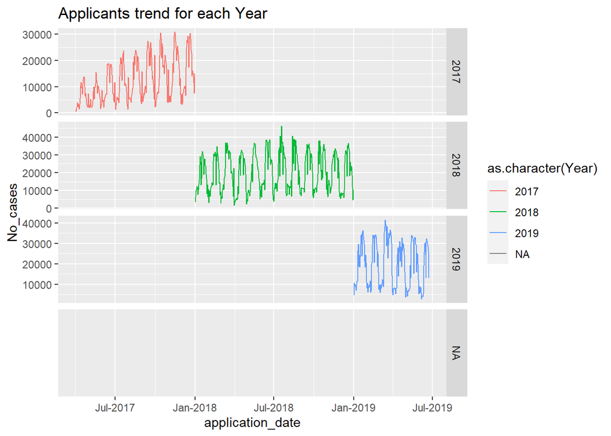

```r
ggplot(na_trend,aes(x = application_date,y = No_cases ,color = as.character(Year)))+geom_line(stat = "identity")+labs(title = "Applicants trend for each Year")+scale_x_date(date_labels = "%b-%Y")+facet_grid(Year~.,scale = "free")
```

###### **Insights:**

There seems to be an upward trend for the year 2017 as well.

The data for the year 2017 seems to be heteroscedastic in nature as well.

The seasonality is clearly visible off the years.

## Working on the atomic level (bottom up approach)

```r
# grouping the data
grouped_df_tibble = df_tsibble %>% group_by(branch_id)
b1 <-  grouped_df_tibble[grouped_df_tibble['branch_id']==1,]
head(b1,10)
```

```
## # A tsibble: 10 x 7 [1]
## # Groups:    branch_id [1]
##    application_date segment branch_id state       zone  no_of_applicants index
##    <date>             <int>     <int> <chr>       <chr>            <int> <int>
##  1 2017-04-01             1         1 WEST BENGAL EAST                40     1
##  2 2017-04-03             1         1 WEST BENGAL EAST                 5    84
##  3 2017-04-04             1         1 WEST BENGAL EAST                 4   167
##  4 2017-04-05             1         1 WEST BENGAL EAST               113   250
##  5 2017-04-07             1         1 WEST BENGAL EAST                76   333
##  6 2017-04-12             1         1 WEST BENGAL EAST               123   416
##  7 2017-04-13             1         1 WEST BENGAL EAST                81   499
##  8 2017-04-14             1         1 WEST BENGAL EAST               117   582
##  9 2017-04-15             1         1 WEST BENGAL EAST               127   665
## 10 2017-04-16             1         1 WEST BENGAL EAST                42   748
```

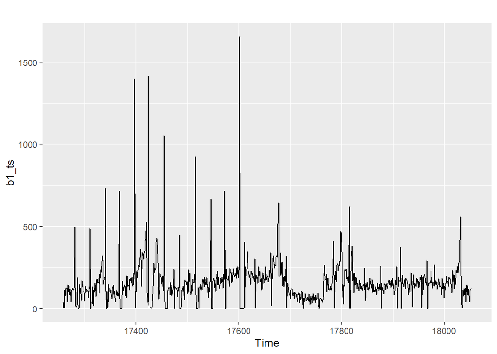

```r
b1_ts = ts(b1$no_of_applicants, start = min(b1$application_date), end = max(b1$application_date))
# time series plot
autoplot(b1_ts)
```

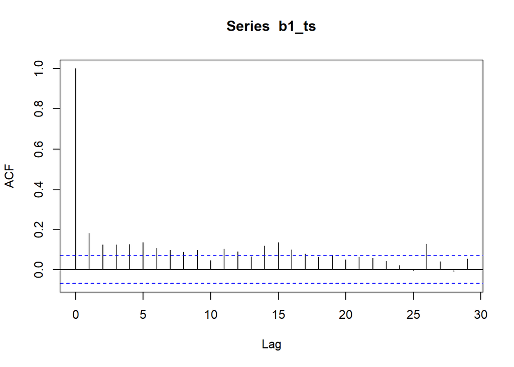

```r
# 1. ACF:
acf(b1_ts)
```

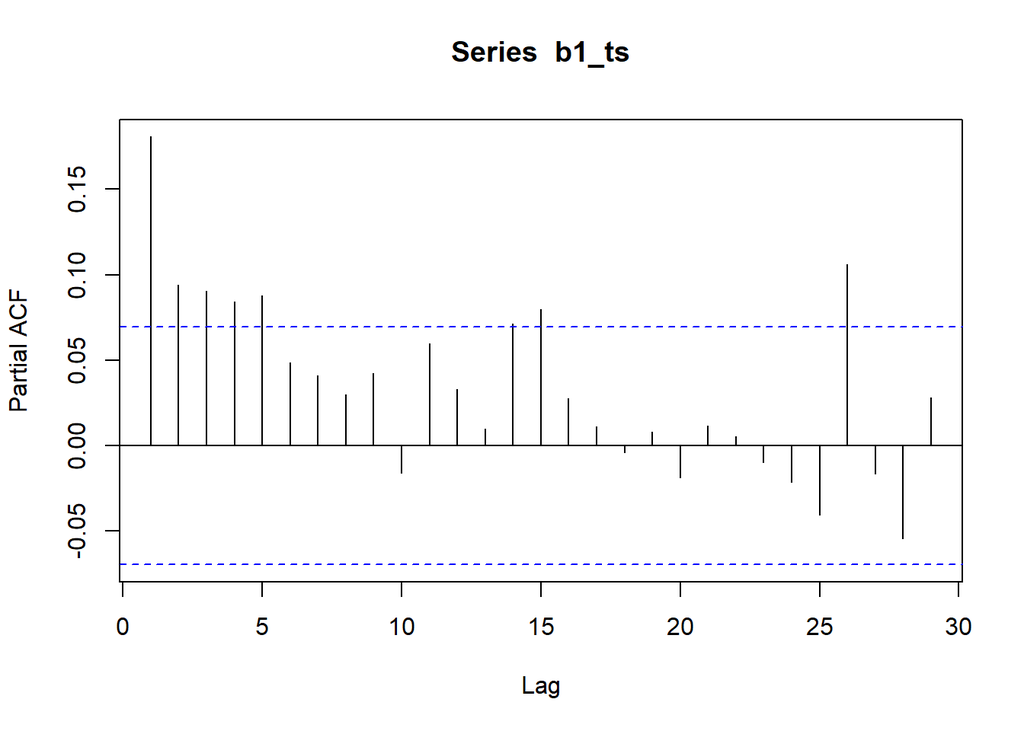

```r
# 2. PACF:
pacf(b1_ts)
```

```r
# 3. ADF test:
# H0 : Data is non-stationary
# H1 : Data is stationary
adf.test(b1_ts)
```

```
##
##  Augmented Dickey-Fuller Test
##
## data:  b1_ts
## Dickey-Fuller = -6.5605, Lag order = 9, p-value = 0.01
## alternative hypothesis: stationary
```

**insights:** the p-value is 0.01 which is <0.05; indicating we need to reject the null hypothesis stating that the data is stationary.

```r
# 4. auto ARIMA
# information criteria (ic) = akaike information criterion ['aic']

b1_model = auto.arima(b1_ts, ic ='aic', trace = TRUE)
```

```
##
##  Fitting models using approximations to speed things up...
##
##  ARIMA(2,0,2) with non-zero mean : Inf
##  ARIMA(0,0,0) with non-zero mean : 10076.56
##  ARIMA(1,0,0) with non-zero mean : 10052.32
##  ARIMA(0,0,1) with non-zero mean : 10056.33
##  ARIMA(0,0,0) with zero mean     : 10758.36
##  ARIMA(2,0,0) with non-zero mean : 10047.23
##  ARIMA(3,0,0) with non-zero mean : 10042.81
##  ARIMA(4,0,0) with non-zero mean : 10040.04
##  ARIMA(5,0,0) with non-zero mean : 10036.68
##  ARIMA(5,0,1) with non-zero mean : 10028.56
##  ARIMA(4,0,1) with non-zero mean : 10025.77
##  ARIMA(3,0,1) with non-zero mean : 10023.91
##  ARIMA(2,0,1) with non-zero mean : 10020.92
##  ARIMA(1,0,1) with non-zero mean : 10018.66
##  ARIMA(1,0,2) with non-zero mean : 10019.28
##  ARIMA(0,0,2) with non-zero mean : 10051.96
##  ARIMA(1,0,1) with zero mean     : Inf
##
##  Now re-fitting the best model(s) without approximations...
##
##  ARIMA(1,0,1) with non-zero mean : 10020.11
##
##  Best model: ARIMA(1,0,1) with non-zero mean
```

**Best model:** ARIMA(1,0,1) with non-zero mean : 10020.11

```r
# 5. model summary:
summary(b1_model)
```

```
## Series: b1_ts
## ARIMA(1,0,1) with non-zero mean
##
## Coefficients:
##          ar1      ma1      mean
##       0.9510  -0.8633  155.7212
## s.e.  0.0223   0.0362   12.7355
##
## sigma^2 estimated as 17044:  log likelihood=-5006.05
## AIC=10020.11   AICc=10020.16   BIC=10038.83
##
## Training set error measures:
##                   ME     RMSE      MAE  MPE MAPE    MASE       ACF1
## Training set 0.69636 130.3081 66.04074 -Inf  Inf 0.90637 0.03535247
```